# dada2_tutorial

James Fifer, Sarah Davies

August 18, 2021

## Guam 2021 Metabarcoding Workshop

### Overview

The following tutorial is modified from: https://benjjneb.github.io/dada2/tutorial.html with edits by Carly D. Kenkel & Alizah Ali & Nicola Kriefall & Sarah Davies & James Fifer

NOTE **The following tutorial assumes you have already removed barcodes and demultiplexed (one fastq per sample). If you have not done so, please check out this [file](https://github.com/jamesfifer/UOG_Metabarcoding_WS/blob/main/Pre-processing.txt) on the github**

**Download the necessary packages**

Download dada2, phyloseq and ShortRead

```r
# source("https://bioconductor.org/biocLite.R")
# biocLite("dada2")
# biocLite('vegan')
# biocLite("phyloseq")

#Depending on the version of R you have, you might have to use BiocManager instead
if (!requireNamespace("BiocManager", quietly = TRUE))
    install.packages("BiocManager")
BiocManager::install("dada2", version = "3.11")
```

if the above does not work you can try the various installation options offered on the dada2 github https://benjjneb.github.io/dada2/dada-installation.html

```r
library(dada2); #packageVersion("dada2"); citation("dada2")
library(ShortRead); #packageVersion("ShortRead")
library(ggplot2); #packageVersion("ggplot2")
library(phyloseq); #packageVersion("phyloseq")
```

NOTE **if phyloseq does not work, try using BiocManager as we did above for dada2.**

Set path to unzipped, renamed fastq files

```r
path <- "~/BOSTON/Guam_16S&ITS2_Workshop/Community_Data/Comm_Data" # CHANGE ME to the directory containing the fastq files after unzipping.

fns <- list.files(path)
```

Let’s make sure that all of our files are there

```r
fns
```

```
##  [1] "Alizah_nochim.csv"                 "Alizah_seqtab.csv"
##  [3] "DIP10.fastq"                       "DIP11.fastq"
##  [5] "DIP12.fastq"                       "DIP13.fastq"
##  [7] "DIP14.fastq"                       "DIP23.fastq"
##  [9] "DZ10C_1.fastq"                     "DZ10C_2.fastq"
## [11] "DZ10C_3.fastq"                     "DZ10C_4.fastq"
## [13] "DZ10C_5.fastq"                     "DZ11C_1.fastq"
## [15] "DZ2B_1.fastq"                      "DZ2C_1.fastq"
## [17] "DZ2C_2.fastq"                      "DZ2C_3.fastq"
## [19] "DZ2C_4.fastq"                      "DZ2C_5.fastq"
## [21] "DZ2C_6.fastq"                      "DZ2C_7.fastq"
## [23] "DZ3C_1.fastq"                      "DZ4A_1.fastq"
## [25] "DZ6A_1.fastq"                      "DZ6A_2_3.fastq"
## [27] "DZ6A_4.fastq"                      "DZ6B_2.fastq"
## [29] "DZ6B_3.fastq"                      "DZ6B_4.fastq"
```

[output cut: 19 more lines]

### Trimming/Filtering

```r
fastqs <- fns[grepl(".fastq$", fns)]
fastqs <- sort(fastqs) # Sort ensures reads are in same order
#fnFs <- fastqs[grepl("_R1", fastqs)] # Just the forward read files- these are old 454 data but most data are paired end

# Get sample names, assuming files named as so: SAMPLENAME_XXX.fastq; OTHERWISE MODIFY
sample.names <- sapply(strsplit(fastqs, ".fastq"), `[`, 1) #the last number will select the field for renaming
head(sample.names)
```

```
## [1] "DIP10" "DIP11" "DIP12" "DIP13" "DIP14" "DIP23"
```

```r
# Specify the full path to the fnFs
fnFs <- file.path(path, fastqs)
head(fnFs)
```

```
## [1] "~/BOSTON/Guam_16S&ITS2_Workshop/Community_Data/Comm_Data/DIP10.fastq"
## [2] "~/BOSTON/Guam_16S&ITS2_Workshop/Community_Data/Comm_Data/DIP11.fastq"
## [3] "~/BOSTON/Guam_16S&ITS2_Workshop/Community_Data/Comm_Data/DIP12.fastq"
## [4] "~/BOSTON/Guam_16S&ITS2_Workshop/Community_Data/Comm_Data/DIP13.fastq"
## [5] "~/BOSTON/Guam_16S&ITS2_Workshop/Community_Data/Comm_Data/DIP14.fastq"
## [6] "~/BOSTON/Guam_16S&ITS2_Workshop/Community_Data/Comm_Data/DIP23.fastq"
```

**Check for primers**

```r
FWD <- "GTGAATTGCAGAACTCCGTG"  ## CHANGE ME to your forward primer sequence
REV <- "CCTCCGCTTACTTATATGCTT"  ## CHANGE ME...

allOrients <- function(primer) {
  # Create all orientations of the input sequence
  require(Biostrings)
  dna <- DNAString(primer)  # The Biostrings works w/ DNAString objects rather than character vectors
  orients <- c(Forward = dna, Complement = complement(dna), Reverse = reverse(dna),
               RevComp = reverseComplement(dna))
  return(sapply(orients, toString))  # Convert back to character vector
}
FWD.orients <- allOrients(FWD)
REV.orients <- allOrients(REV)
FWD.orients
```

```
##                Forward             Complement                Reverse
## "GTGAATTGCAGAACTCCGTG" "CACTTAACGTCTTGAGGCAC" "GTGCCTCAAGACGTTAAGTG"
##                RevComp
## "CACGGAGTTCTGCAATTCAC"
```

```r
REV.orients
```

```
##                 Forward              Complement                 Reverse
## "CCTCCGCTTACTTATATGCTT" "GGAGGCGAATGAATATACGAA" "TTCGTATATTCATTCGCCTCC"
##                 RevComp
## "AAGCATATAAGTAAGCGGAGG"
```

```r
primerHits <- function(primer, fn) {
  # Counts number of reads in which the primer is found
  nhits <- vcountPattern(primer, sread(readFastq(fn)), fixed = FALSE)
  return(sum(nhits > 0))
}

rbind(FWD.ForwardReads = sapply(FWD.orients, primerHits, fn = fnFs[[2]]),
     # FWD.ReverseReads = sapply(FWD.orients, primerHits, fn = fnRs[[2]]), #You can uncomment this line if you have reversereads
      REV.ForwardReads = sapply(REV.orients, primerHits, fn = fnFs[[2]])#,
     # REV.ReverseReads = sapply(REV.orients, primerHits, fn = fnRs.filtN[[2]])#You can uncomment this line if you have reversereads
     )
```

```
##                  Forward Complement Reverse RevComp
## FWD.ForwardReads      37         31      37    1057
## REV.ForwardReads    1164         34      31      30
```

### Visualize Raw data

First, lets look at quality profile of R1 reads

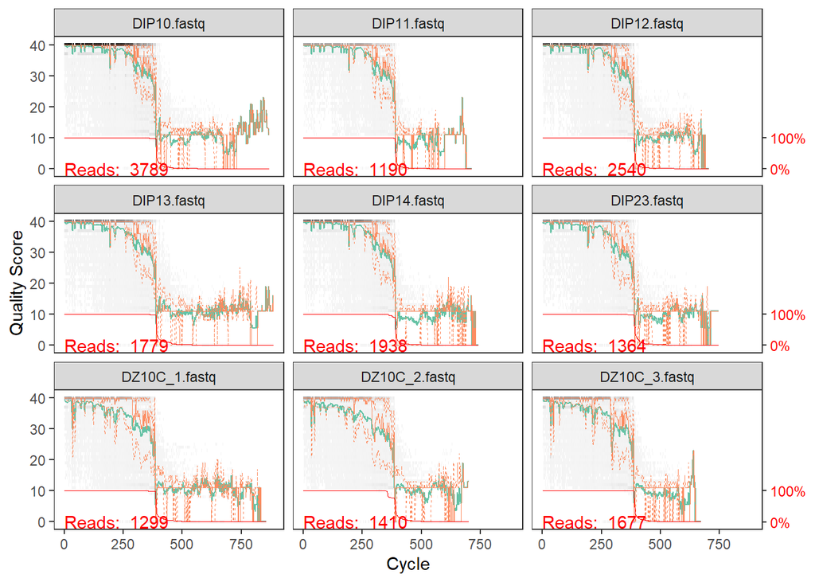

```r
plotQualityProfile(fnFs[c(1,2,3,4,5,6,7,8,9)])
```

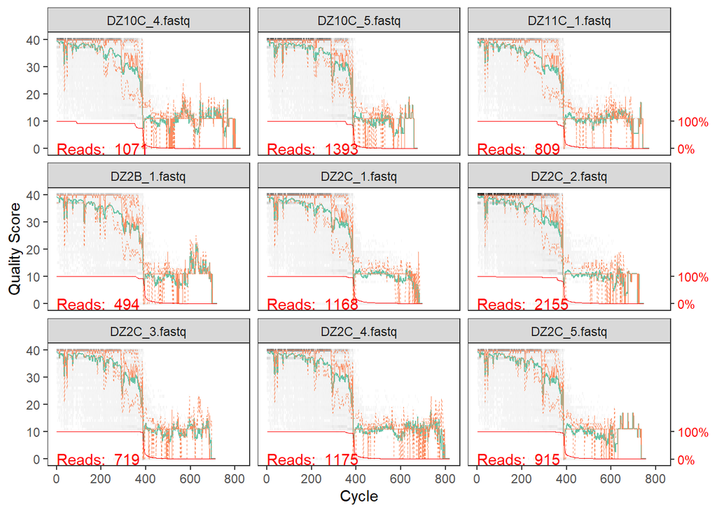

```r
plotQualityProfile(fnFs[c(10,11,12,13,14,15,16,17,18)])
```

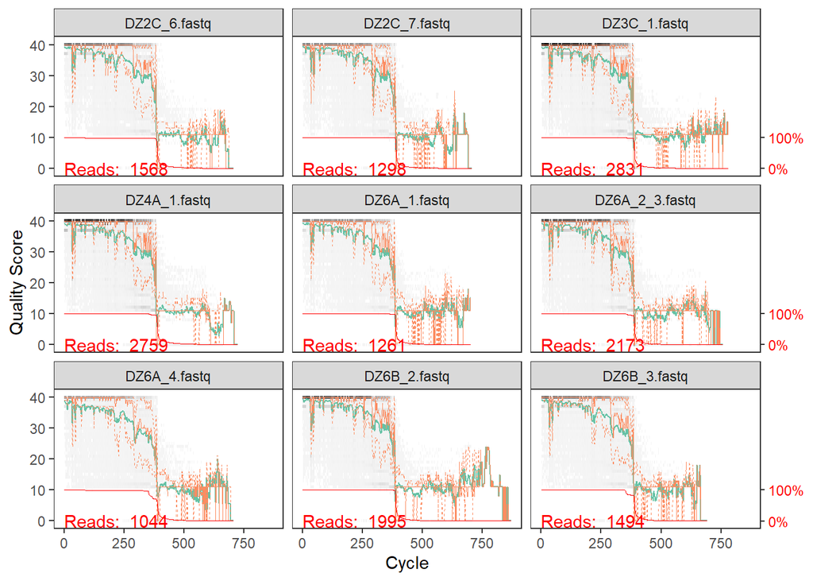

```r
plotQualityProfile(fnFs[c(19,20,21,22,23,24,25,26,27)])
```

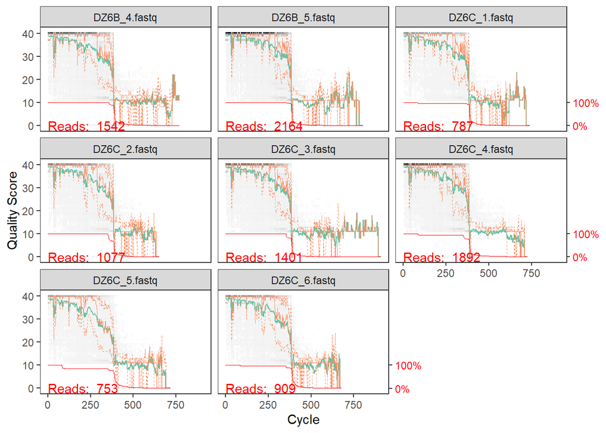

```r
plotQualityProfile(fnFs[c(28,29,30,31,32,33,34,35)])
```

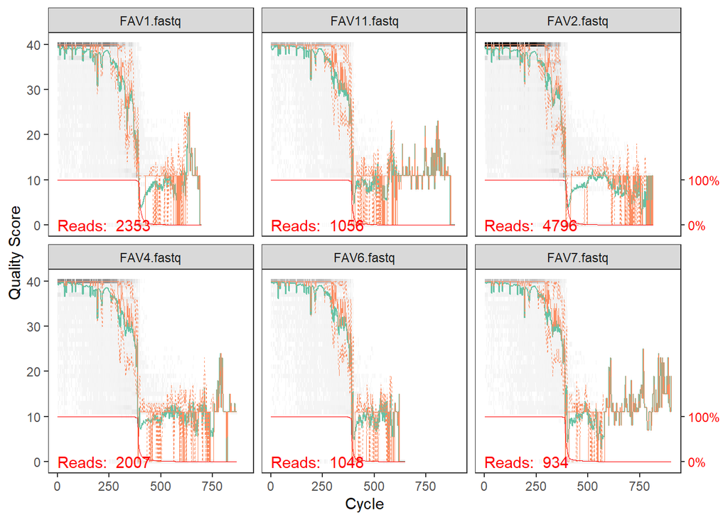

```r
plotQualityProfile(fnFs[c(36,37,38,39,40,41)])
```

```r
#Recommend trimming where quality profile crashes - in this case, forward reads mostly fine up to 300
#For common ITS amplicon strategies with paired end reads, it is undesirable to truncate reads to a fixed length due to the large amount of length variation at that locus. That is OK, just leave out truncLen. Make sure you removed the forward and reverse primers from both the forward and reverse reads though!
```

Make directory and filenames for the filtered fastqs

```r
filt_path <- file.path(path, "trimmed")
if(!file_test("-d", filt_path)) dir.create(filt_path)
filtFs <- file.path(filt_path, paste0(sample.names, "_F_filt.fastq.gz"))

# Filter
out <- filterAndTrim(fnFs, filtFs, truncLen= 300, #end of single end reads = approx. 300 bp
                     maxN=0, #DADA does not allow Ns
                     maxEE=1, #allow 1 expected errors, where EE = sum(10^(-Q/10)); more conservative, model converges
                     truncQ=2,
                     trimLeft=20, #N nucleotides to remove from the start of each read: ITS2 primer = F 20bp
                     rm.phix=TRUE, #remove reads matching phiX genome
                     compress=TRUE, multithread=FALSE) # On Windows set multithread=FALSE

head(out)
```

```
##             reads.in reads.out
## DIP10.fastq     3789      3535
## DIP11.fastq     1190      1117
## DIP12.fastq     2540      2385
## DIP13.fastq     1779      1604
## DIP14.fastq     1938      1785
## DIP23.fastq     1364      1250
```

```r
tail(out)
```

```
##             reads.in reads.out
## FAV1.fastq      2353      2143
## FAV11.fastq     1056       983
## FAV2.fastq      4796      4338
## FAV4.fastq      2007      1830
## FAV6.fastq      1048       990
## FAV7.fastq       934       876
```

A word on Expected Errors vs a blanket quality threshold Take a simple example: a read of length two with quality scores Q3 and Q40, corresponding to error probabilities P=0.5 and P=0.0001. The base with Q3 is much more likely to have an error than the base with Q40 (0.5/0.0001 = 5,000 times more likely), so we can ignore the Q40 base to a good approximation. Consider a large sample of reads with (Q3, Q40), then approximately half of them will have an error (because of the P=0.5 from the Q2 base). We express this by saying that the expected number of errors in a read with quality scores (Q3, Q40) is 0.5. As this example shows, low Q scores (high error probabilities) dominate expected errors, but this information is lost by averaging if low Qs appear in a read with mostly high Q scores. This explains why expected errors is a much better indicator of read accuracy than average Q.

NOTE **At this step it is often a good idea to make sure primers are removed now.**

If they are not you can use the following code to remove primers.

```r
cutadapt <- "/home/jamesf/.local/bin/cutadapt" # CHANGE ME TO WHEREVER YOU HAVE INSTALLED CUTADAPT
system2(cutadapt, args = "--version")

path.cut <- file.path(path, "cutadapt")
if(!dir.exists(path.cut)) dir.create(path.cut)
fnFs.cut <- file.path(path.cut, basename(fnFs))
fnRs.cut <- file.path(path.cut, basename(fnRs))

FWD.RC <- dada2:::rc(FWD)
REV.RC <- dada2:::rc(REV)
# Trim FWD and the reverse-complement of REV off of R1 (forward reads)
R1.flags <- paste("-g", FWD, "-a", REV.RC)
# Trim REV and the reverse-complement of FWD off of R2 (reverse reads)
R2.flags <- paste("-G", REV, "-A", FWD.RC)
```

Before running, need to gunzip fastqs and then rename so it ends with fastq in TERMINAL:

```bash
gunzip -S .fastq *.fastq
for file in *_ITS; do     mv "$file" "${file%}.fastq"; done
```

Back in R

```r
for(i in seq_along(fnFs)) {
  system2(cutadapt, args = c(R1.flags, R2.flags, "-n", 2, # -n 2 required to remove FWD and REV from reads
                             "-o", fnFs.cut[i], "-p", fnRs.cut[i], # output files
                             fnFs.filtN[i], fnRs.filtN[i])) # input files
}

rbind(FWD.ForwardReads = sapply(FWD.orients, primerHits, fn = fnFs.cut[[1]]),
      FWD.ReverseReads = sapply(FWD.orients, primerHits, fn = fnRs.cut[[1]]),
      REV.ForwardReads = sapply(REV.orients, primerHits, fn = fnFs.cut[[1]]),
      REV.ReverseReads = sapply(REV.orients, primerHits, fn = fnRs.cut[[1]]))
```

### Learn Error Rates

DADA2 learns its error model from the data itself by alternating estimation of the error rates and the composition of the sample until they converge on a jointly consistent solution (this is similar to the E-M algorithm) As in many optimization problems, the algorithm must begin with an initial guess, for which the maximum possible error rates in this data are used (the error rates if only the most abundant sequence is correct and all the rest are errors).

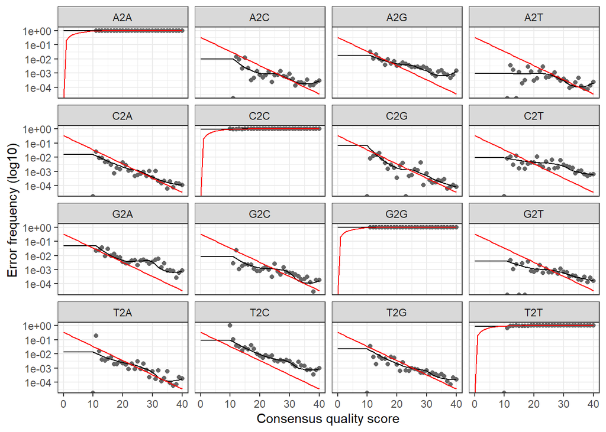

```r
setDadaOpt(MAX_CONSIST=30) #increase number of cycles to allow convergence
errF <- learnErrors(filtFs, multithread=TRUE)
#Maximum cycles was set to 30, but Convergence was found after 4 rounds

#sanity check: visualize estimated error rates
#error rates should decline with increasing qual score
#red line is based on definition of quality score alone
#black line is estimated error rate after convergence
#dots are observed error rate for each quality score

plotErrors(errF, nominalQ=TRUE)
```

### Dereplicate reads and infer ASVs

**Dereplicate**

Dereplication combines all identical sequencing reads into a unique sequence with a corresponding abundance: the number of reads with that unique sequence. Dereplication substantially reduces computation time by eliminating redundant comparisons. DADA2 retains a summary of the quality information associated with each unique sequence. The consensus quality profile of a unique sequence is the average of the positional qualities from the dereplicated reads. These quality profiles inform the error model of the subsequent denoising step, significantly increasing DADA2’s accuracy.

```r
derepFs <- derepFastq(filtFs, verbose=TRUE)
```

Name the derep-class objects by the sample names

```r
names(derepFs) <- sample.names
```

**Infer Sequence Variants**

Must change some of the DADA options b/c original program optomized for ribosomal data, not ITS - from github, “We currently recommend BAND_SIZE=32 for ITS data.” leave as default for 16S/18S Band size is the limit for number of gaps that one sequence has relative to another sequence. If it goes above this limit dada2 will not try to align these two sequences. Important to increase this if you have lots of expected indels (creates lots of gaps) ITS2 regions are indel rich compared to 16s, hence the importance of changing it from default for ITS2 analysis.

NOTE **This is the line where we would add pool=TRUE or pool=pseudo (if we were dealing with a HUGE dataset). For now we will just do the default behavior because it takes less time, but for your own data you should add pool=TRUE**

```r
setDadaOpt(BAND_SIZE=32)
dadaFs <- dada(derepFs, err=errF, multithread=TRUE)
```

now, look at the dada class objects by sample will tell how many ‘real’ variants in unique input seqs By default, the dada function processes each sample independently, but pooled processing is available with pool=TRUE and that may give better results for low sampling depths at the cost of increased computation time. See our discussion about pooling samples for sample inference.

```r
dadaFs[[1]]
```

```
## dada-class: object describing DADA2 denoising results
## 6 sequence variants were inferred from 367 input unique sequences.
## Key parameters: OMEGA_A = 1e-40, OMEGA_C = 1e-40, BAND_SIZE = 32
```

```r
dadaFs[[25]]
```

```
## dada-class: object describing DADA2 denoising results
## 7 sequence variants were inferred from 287 input unique sequences.
## Key parameters: OMEGA_A = 1e-40, OMEGA_C = 1e-40, BAND_SIZE = 32
```

[output not shown]

### Remove chimeras

The core dada method removes substitution and indel errors, but chimeras remain. Fortunately, the accuracy of the sequences after denoising makes identifying chimeras easier than it is when dealing with fuzzy OTUs: all sequences which can be exactly reconstructed as a bimera (two-parent chimera) from more abundant sequences.

```r
seqtab.nochim <- removeBimeraDenovo(seqtab, method="consensus", multithread=TRUE, verbose=TRUE)
```

```
## Identified 0 bimeras out of 123 input sequences.
```

```r
dim(seqtab.nochim)
```

```
## [1]  41 123
```

```r
sum(seqtab.nochim)/sum(seqtab)
```

```
## [1] 1
```

**Write sequence tables so we can read them in later without running all the previous code**

```r
write.csv(seqtab,file="Alizah_seqtab.csv")
write.csv(seqtab.nochim,file="Alizah_nochim.csv")
```

### Track Read Stats

```r
getN <- function(x) sum(getUniques(x))
track <- cbind(out, sapply(dadaFs, getN), sapply(dadaFs, getN), rowSums(seqtab), rowSums(seqtab.nochim))
colnames(track) <- c("input", "filtered", "denoised", "merged", "tabled", "nonchim")
rownames(track) <- sample.names
head(track)
```

```
##       input filtered denoised merged tabled nonchim
## DIP10  3789     3535     3506   3506   3506    3506
## DIP11  1190     1117     1105   1105   1105    1105
## DIP12  2540     2385     2385   2385   2385    2385
## DIP13  1779     1604     1604   1604   1604    1604
## DIP14  1938     1785     1751   1751   1751    1751
## DIP23  1364     1250     1250   1250   1250    1250
```

```r
tail(track)
```

```
##       input filtered denoised merged tabled nonchim
## FAV1   2353     2143     2143   2143   2143    2143
## FAV11  1056      983      983    983    983     983
## FAV2   4796     4338     4338   4338   4338    4338
## FAV4   2007     1830     1830   1830   1830    1830
## FAV6   1048      990      990    990    990     990
## FAV7    934      876      876    876    876     876
```

```r
write.csv(track,file="ReadFilterStats_AllData_final.csv",row.names=TRUE,quote=FALSE)
```

### Assign Taxonomy

It is common at this point, especially in 16S/18S/ITS amplicon sequencing, to classify sequence variants taxonomically. DADA2 provides a native implementation of the RDP’s naive Bayesian classifier. The assignTaxonomy function takes a set of sequences and a training set of taxonomically classified sequences, and outputs the taxonomic assignments with at least minBoot bootstrap confidence. Here, I have supplied a modified version of the GeoSymbio ITS2 database listing more taxonomic info as phyloseq requires (Franklin et al. 2012) For example: GeoSymbio data (taken from “all clades” at https://sites.google.com/site/geosymbio/downloads): >A1.1 modified version for phyloseq looks like this instead: >Symbiodinium; Clade A; A1.1

```r
taxa <- assignTaxonomy(seqtab.nochim, "../GeoSymbio_ITS2_LocalDatabase_verForPhyloseq.fasta", minBoot=5,multithread=TRUE,tryRC=TRUE,outputBootstraps=FALSE)
```

NOTE **When you do this on your own data, minboot should be higher (at least 50). We are doing 5 for the sake of time**

NOTE **When you do this on your own data makesure to download the latest GeoSymbio database, it is occasionally updated.**

Obtain a csv file for the taxonomy so that it’s easier to map the sequences for the heatmap.

```r
write.csv(taxa, file="taxa.csv",row.name=TRUE,quote=FALSE)
unname(head(taxa, 30))
```

```
##       [,1]           [,2]       [,3]
##  [1,] "Symbiodinium" " Clade B" " B1"
##  [2,] "Symbiodinium" " Clade B" " B2"
##  [3,] "Symbiodinium" " Clade B" " B3"
##  [4,] "Symbiodinium" " Clade B" " B3"
##  [5,] "Symbiodinium" " Clade B" " B2"
##  [6,] "Symbiodinium" " Clade B" " B3"
##  [7,] "Symbiodinium" " Clade B" " B3"
##  [8,] "Symbiodinium" " Clade B" " B2"
##  [9,] "Symbiodinium" " Clade B" " B3"
## [10,] "Symbiodinium" " Clade B" " B2"
## [11,] "Symbiodinium" " Clade B" " B1"
## [12,] "Symbiodinium" " Clade B" " B14"
## [13,] "Symbiodinium" " Clade B" " B2"
## [14,] "Symbiodinium" " Clade B" " B14"
```

[output cut: 16 more lines]

```r
unname(taxa)
```

```
##        [,1]           [,2]       [,3]
##   [1,] "Symbiodinium" " Clade B" " B1"
##   [2,] "Symbiodinium" " Clade B" " B2"
##   [3,] "Symbiodinium" " Clade B" " B3"
##   [4,] "Symbiodinium" " Clade B" " B3"
##   [5,] "Symbiodinium" " Clade B" " B2"
##   [6,] "Symbiodinium" " Clade B" " B3"
##   [7,] "Symbiodinium" " Clade B" " B3"
##   [8,] "Symbiodinium" " Clade B" " B2"
##   [9,] "Symbiodinium" " Clade B" " B3"
##  [10,] "Symbiodinium" " Clade B" " B2"
##  [11,] "Symbiodinium" " Clade B" " B1"
##  [12,] "Symbiodinium" " Clade B" " B14"
##  [13,] "Symbiodinium" " Clade B" " B2"
##  [14,] "Symbiodinium" " Clade B" " B14"
```

[output cut: 109 more lines]

Now, save outputs so can come back to the analysis stage at a later point if desired

```r
saveRDS(seqtab.nochim, file="final_seqtab_nochim.rds")
saveRDS(taxa, file="final_taxa_blastCorrected.rds")
```

```r
#If you need to read in previously saved datafiles
seqtab.nochim <- readRDS("final_seqtab_nochim.rds")
taxa <- readRDS("final_taxa_blastCorrected.rds")
head(taxa)
```

```
##                                                                                                                                                                                                                                                                                          Kingdom
## TACTTATATGCTTAAATTCAGCGGGTTCTCTTGTCTGACTTCATGCTAAGGGCATGCATC… "Symbiodinium"
## TACTTATATGCTTAAATTCAGCGGGTTCTCTTGTCTGACTTCATGCTAAGGGCATGCATC… "Symbiodinium"
## TACTTATATGCTTAAATTCAGCGGGTTCTCTTGTCTGACTTCATGCTAAGGGCATGCATC… "Symbiodinium"
## TACTTATATGCTTAAATTCAGCGGGTTCTCTTGTCTGACTTCATGCTAAGGGCATGCATC… "Symbiodinium"
## TACTTATATGCTTAAATTCAGCGGGTTTCTCTTGTCTGACTTCATGCTAAGGGCATGCAT… "Symbiodinium"
## TACTTATATGCTTAAATTCAGCGGGTTTCTCTTGTCTGACTTCATGCTAAGGGCATGCAT… "Symbiodinium"
##                                                                                                                                                                                                                                                                                          Phylum
## TACTTATATGCTTAAATTCAGCGGGTTCTCTTGTCTGACTTCATGCTAAGGGCATGCATC… " Clade B"
## TACTTATATGCTTAAATTCAGCGGGTTCTCTTGTCTGACTTCATGCTAAGGGCATGCATC… " Clade B"
## TACTTATATGCTTAAATTCAGCGGGTTCTCTTGTCTGACTTCATGCTAAGGGCATGCATC… " Clade B"
## TACTTATATGCTTAAATTCAGCGGGTTCTCTTGTCTGACTTCATGCTAAGGGCATGCATC… " Clade B"
## TACTTATATGCTTAAATTCAGCGGGTTTCTCTTGTCTGACTTCATGCTAAGGGCATGCAT… " Clade B"
## TACTTATATGCTTAAATTCAGCGGGTTTCTCTTGTCTGACTTCATGCTAAGGGCATGCAT… " Clade B"
##                                                                                                                                                                                                                                                                                          Class
## TACTTATATGCTTAAATTCAGCGGGTTCTCTTGTCTGACTTCATGCTAAGGGCATGCATC… " B1"
## TACTTATATGCTTAAATTCAGCGGGTTCTCTTGTCTGACTTCATGCTAAGGGCATGCATC… " B2"
## TACTTATATGCTTAAATTCAGCGGGTTCTCTTGTCTGACTTCATGCTAAGGGCATGCATC… " B3"
## TACTTATATGCTTAAATTCAGCGGGTTCTCTTGTCTGACTTCATGCTAAGGGCATGCATC… " B3"
## TACTTATATGCTTAAATTCAGCGGGTTTCTCTTGTCTGACTTCATGCTAAGGGCATGCAT… " B2"
## TACTTATATGCTTAAATTCAGCGGGTTTCTCTTGTCTGACTTCATGCTAAGGGCATGCAT… " B3"
```

### Additional filtering

**We will be skipping these steps for the workshop**

**Two additional steps for removing negative control and other sequences from unwanted DNA**

**Additional filtering step 1: removing negative Control**

First we need to create a fasta file from our ASV sequences

```r
asv_seqs <- colnames(seqtab.nochim)
asv_headers <- vector(dim(seqtab.nochim)[2], mode="character")
for (i in 1:dim(seqtab.nochim)[2]) {
  asv_headers[i] <- paste(">ASV", i, sep="_")
}

# making and writing out a fasta of our final ASV seqs:
asv_fasta <- c(rbind(asv_headers, asv_seqs))
write(asv_fasta, "ASVs.fa")

# count table:
asv_tab <- t(seqtab.nochim)
row.names(asv_tab) <- sub(">", "", asv_headers)
write.table(asv_tab, "ASVs_counts.tsv", sep="\t", quote=F, col.names=NA)

# tax table:
asv_tax <- taxa
row.names(asv_tax) <- sub(">", "", asv_headers)
write.table(asv_tax, "ASVs_taxonomy.tsv", sep="\t", quote=F, col.names=NA)

#Install the package decontaim
BiocManager::install("decontam")
library(decontam)

colnames(asv_tab) # our blanks are the 4th sample in this example
vector_for_decontam <- c(rep(FALSE, 3), rep(TRUE, 1), rep(FALSE, 92))
vector_for_decontam

contam_df <- isContaminant(t(asv_tab), neg=vector_for_decontam)

table(contam_df$contaminant) # identified X# of ASVs as contaminants

# getting vector holding the identified contaminant IDs
contam_asvs <- row.names(contam_df[contam_df$contaminant == TRUE, ])
contam_asvs
#Print the ASVs identified as contaminants
asv_tax[row.names(asv_tax) %in% contam_asvs, ]
#Copy those ASVs here:
#[1] "ASV_153"  "ASV_155"  "ASV_191"  "ASV_232"  "ASV_647"  "ASV_775"  "ASV_824"  "ASV_868"
#[9] "ASV_994"  "ASV_1108" "ASV_1273" "ASV_1363" "ASV_1621" "ASV_1767" "ASV_2726" "ASV_2910"

#OPTIONAL If you want to see what those sequences look like in your TERMINAL you would run the following line
#grep -w -A1 "^>ASV_38\|^>ASV_152\|^>ASV_154\|^>ASV_193\|^>ASV_199\|^>ASV_308\|^>ASV_321\|^>ASV_337\|^>ASV_632\|^>ASV_636\|^>ASV_810\|^>ASV_915\|^>ASV_1129\|^>ASV_1326\|^>ASV_1377\|^>ASV_1706\|^>ASV_1865\|^>ASV_2221\|^>ASV_2632\" ASVs.fa


# making new fasta file
contam_indices <- which(asv_fasta %in% paste0(">", contam_asvs))
test_indices=which(asv_fasta %in% paste0(">", nas_asvs_names))
dont_want <- sort(c(contam_indices, contam_indices + 1))
asv_fasta_no_contam <- asv_fasta[- dont_want]

# making new count table
asv_tab_no_contam <- asv_tab[!row.names(asv_tab) %in% contam_asvs, ]

# making new taxonomy table
asv_tax_no_contam <- asv_tax[!row.names(asv_tax) %in% contam_asvs, ]

## and now writing them out to files
write(asv_fasta_no_contam, "ASVs-no-contam.fa")
write.table(asv_tab_no_contam, "ASVs_counts-no-contam.tsv",
            sep="\t", quote=F, col.names=NA)
write.table(asv_tax_no_contam, "ASVs_taxonomy-no-contam.tsv",
            sep="\t", quote=F, col.names=NA)


count_tab <- read.table("ASVs_counts-no-contam.tsv", header=T,row.names = 1,
                        check.names=F, sep="\t")[ , -c(4)]

tax_tab <- as.matrix(read.table("ASVs_taxonomy-no-contam.tsv", header=T,
                                row.names=1, check.names=F, sep="\t"))
```

**Additional filtering step 2: checking external database (NCBI) for eukaryotic contamination**

In TERMINAL, identify all sequences that hit eukaryote

```bash
blastn -query ASV.fa  -db /ncbi/NT/nt -outfmt 6 -num_threads $nthreads -evalue 1e-5 -max_target_seqs 10 -out outputfile.txt
#We want to take the NCBI acc numbers from the blast output find the taxa ID and then use taxon kit
first take NCBI accession numbers
cut -f2 nt.blast.out --output-delimiter='|' |rev| cut -f2 -d '|' |rev > NCBI_acc.input
results=();cat NCBI_acc.input | while read p ;do results=($(efetch -db nuccore -id "$p" -format docsum |\
xtract -pattern DocumentSummary -element TaxId)); echo "$p" "${results[@]}" >> NCBI_acc.output; done
cut -f2 NCBI_acc.output -d " ">taxa.ID

#get the taxonomy ID files
wget ftp://ftp.ncbi.nlm.nih.gov/pub/taxonomy/taxdump.tar.Z
#unzip file to get .dmp files
#directory below is location of .dmp files
taxonkit lineage --data-dir "/directory/for/dmpfiles/"  ./taxa.ID > taxa.ID.output
cut -f1 nt.blast.out>taxa.seq.ID; paste taxa.seq.ID taxa.ID.output > taxa.ID.output.withseq
grep "Eukaryota" taxa.ID.output.withseq | cut -f1 | sort | uniq >euk_contam_asvs
```

**Back in** R

Now create new lists without eukaryotes

```r
euk_contam_asvs=read.table(file="euk_contam_asvs",fill = TRUE, stringsAsFactors = FALSE)
euk_contam_asvs=euk_contam_asvs$V1
euk_contam_asvs
# making new count table
asv_tab_no_euk_contam <- asv_tab[!row.names(count_tab) %in% euk_contam_asvs, ]

# making new taxonomy table
asv_tax_no_euk_contam <- asv_tax[!row.names(tax_tab) %in% euk_contam_asvs, ]


#make new counts files

write.table(asv_tab_no_euk_contam, "ASVs_counts-no-euk-contam.tsv",
            sep="\t", quote=F, col.names=NA)
write.table(asv_tax_no_euk_contam, "ASVs_taxonomy-no-euk-contam.tsv",
            sep="\t", quote=F, col.names=NA)


new_count_tab <- read.table("ASVs_counts-no-euk-contam.tsv", header=T,row.names = 1,
                            check.names=F, sep="\t")[ , -c(4)]

new_tax_tab <- as.matrix(read.table("ASVs_taxonomy-no-euk-contam.tsv", header=T,
                                    row.names=1, check.names=F, sep="\t"))


#Check dada2's taxonomy assignment, sometimes with corals for 16S sequencing there will sequences assigned to
#unwated host or symbiont contamination
#Remove any chloroplast, mitochondrial data or other eukaryotic data if you are doing 16S
##removing chloroplast
library(stringr)

new_tax_tab_dat= data.frame(new_tax_tab)
is.chloro= rownames(new_tax_tab_dat[new_tax_tab_dat$Order == "Chloroplast",])
is.chloro=is.chloro[!str_detect(is.chloro,pattern="NA")]

is.mito= rownames(new_tax_tab_dat[new_tax_tab_dat$Family == "Mitochondria",])
is.mito=is.mito[!str_detect(is.mito,pattern="NA")]
is.mito.chloro=append(is.mito, is.chloro)

is.euk=rownames(new_tax_tab_dat[new_tax_tab_dat$Kingdom == "Eukaryota",])
is.euk=is.euk[!str_detect(is.euk,pattern="NA")]
is.mito.chloro=append(is.mito, is.chloro)
is.mito.chloro.euk=append(is.mito.chloro, is.euk)

is.arch=rownames(new_tax_tab_dat[new_tax_tab_dat$Kingdom == "Archaea",])
is.mito.chloro.euk.arch=append(is.mito.chloro.euk, is.arch)
new_count_tab.no.chloro.mito.euk.arch  = new_count_tab[!row.names(new_count_tab)%in%is.mito.chloro.euk.arch,]

#make sure you have deleted the neg control from the sample_info sheet
meta = meta[-1,]
df[match(target, df$name),]
meta=meta[ (colnames(new_count_tab)), ]

tax_tab_phy <- tax_table(new_tax_tab)

#hand off 2 phyloseq
ps2 <- phyloseq(otu_table(new_count_tab.no.chloro.mito.euk.arch, taxa_are_rows=T),
                sample_data(meta),
                tax_table(tax_tab_phy))
```

### handoff 2 phyloseq

**Workshop Resumes**

```r
#import dataframe holding sample information
#have your samples in the same order as the seqtab file in the rows, variables as columns
samdf<-read.csv("../variabletable.csv")
head(samdf)
```

```
##   X sample tank  type
## 1 1  DIP10  DIP adult
## 2 2  DIP11  DIP adult
## 3 3  DIP12  DIP adult
## 4 4  DIP13  DIP adult
## 5 5  DIP14  DIP adult
## 6 6  DIP23  DIP adult
```

```r
head(seqtab.nochim)
```

```
##       TACTTATATGCTTAAATTCAGCGGGTTCTCTTGTCTGACTTCATGCTAAGGGCATGCATC…
## DIP10                                                                                                                                                                                                                                                                                     3311
## DIP11                                                                                                                                                                                                                                                                                      858
## DIP12                                                                                                                                                                                                                                                                                     1726
## DIP13                                                                                                                                                                                                                                                                                     1360
## DIP14                                                                                                                                                                                                                                                                                     1362
## DIP23                                                                                                                                                                                                                                                                                      726
##       TACTTATATGCTTAAATTCAGCGGGTTCTCTTGTCTGACTTCATGCTAAGGGCATGCATC…
## DIP10                                                                                                                                                                                                                                                                                        0
## DIP11                                                                                                                                                                                                                                                                                        0
## DIP12                                                                                                                                                                                                                                                                                        0
## DIP13                                                                                                                                                                                                                                                                                        0
## DIP14                                                                                                                                                                                                                                                                                        0
## DIP23                                                                                                                                                                                                                                                                                        0
##       TACTTATATGCTTAAATTCAGCGGGTTCTCTTGTCTGACTTCATGCTAAGGGCATGCATC…
## DIP10                                                                                                                                                                                                                                                                                        0
## DIP11                                                                                                                                                                                                                                                                                        0
```

[output cut: 844 more lines]

```r
head(taxa)
```

```
##                                                                                                                                                                                                                                                                                          Kingdom
## TACTTATATGCTTAAATTCAGCGGGTTCTCTTGTCTGACTTCATGCTAAGGGCATGCATC… "Symbiodinium"
## TACTTATATGCTTAAATTCAGCGGGTTCTCTTGTCTGACTTCATGCTAAGGGCATGCATC… "Symbiodinium"
## TACTTATATGCTTAAATTCAGCGGGTTCTCTTGTCTGACTTCATGCTAAGGGCATGCATC… "Symbiodinium"
## TACTTATATGCTTAAATTCAGCGGGTTCTCTTGTCTGACTTCATGCTAAGGGCATGCATC… "Symbiodinium"
## TACTTATATGCTTAAATTCAGCGGGTTTCTCTTGTCTGACTTCATGCTAAGGGCATGCAT… "Symbiodinium"
## TACTTATATGCTTAAATTCAGCGGGTTTCTCTTGTCTGACTTCATGCTAAGGGCATGCAT… "Symbiodinium"
##                                                                                                                                                                                                                                                                                          Phylum
## TACTTATATGCTTAAATTCAGCGGGTTCTCTTGTCTGACTTCATGCTAAGGGCATGCATC… " Clade B"
## TACTTATATGCTTAAATTCAGCGGGTTCTCTTGTCTGACTTCATGCTAAGGGCATGCATC… " Clade B"
## TACTTATATGCTTAAATTCAGCGGGTTCTCTTGTCTGACTTCATGCTAAGGGCATGCATC… " Clade B"
## TACTTATATGCTTAAATTCAGCGGGTTCTCTTGTCTGACTTCATGCTAAGGGCATGCATC… " Clade B"
## TACTTATATGCTTAAATTCAGCGGGTTTCTCTTGTCTGACTTCATGCTAAGGGCATGCAT… " Clade B"
## TACTTATATGCTTAAATTCAGCGGGTTTCTCTTGTCTGACTTCATGCTAAGGGCATGCAT… " Clade B"
##                                                                                                                                                                                                                                                                                          Class
## TACTTATATGCTTAAATTCAGCGGGTTCTCTTGTCTGACTTCATGCTAAGGGCATGCATC… " B1"
## TACTTATATGCTTAAATTCAGCGGGTTCTCTTGTCTGACTTCATGCTAAGGGCATGCATC… " B2"
## TACTTATATGCTTAAATTCAGCGGGTTCTCTTGTCTGACTTCATGCTAAGGGCATGCATC… " B3"
## TACTTATATGCTTAAATTCAGCGGGTTCTCTTGTCTGACTTCATGCTAAGGGCATGCATC… " B3"
## TACTTATATGCTTAAATTCAGCGGGTTTCTCTTGTCTGACTTCATGCTAAGGGCATGCAT… " B2"
## TACTTATATGCTTAAATTCAGCGGGTTTCTCTTGTCTGACTTCATGCTAAGGGCATGCAT… " B3"
```

```r
rownames(samdf) <- samdf$sample

# Construct phyloseq object (straightforward from dada2 outputs)
ps <- phyloseq(otu_table(seqtab.nochim, taxa_are_rows=FALSE),
               sample_data(samdf),
               tax_table(taxa))
ps
```

```
## phyloseq-class experiment-level object
## otu_table()   OTU Table:         [ 123 taxa and 41 samples ]
## sample_data() Sample Data:       [ 41 samples by 4 sample variables ]
## tax_table()   Taxonomy Table:    [ 123 taxa by 3 taxonomic ranks ]
```

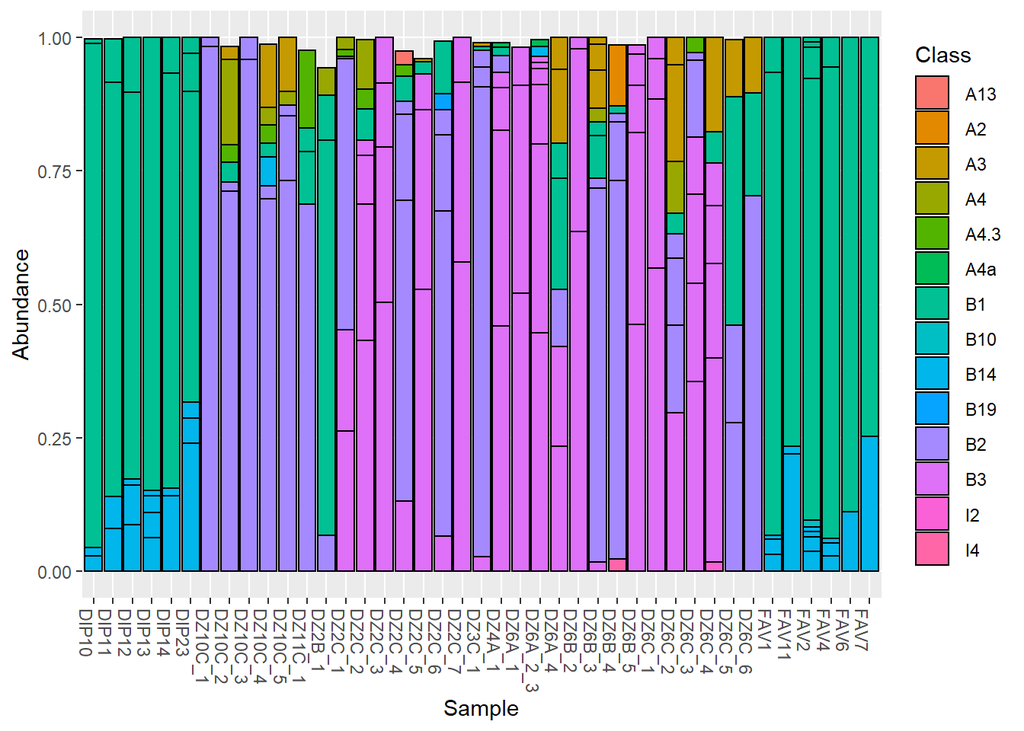

```r
#replace sequences with shorter names (correspondence table output below)
ids<-taxa_names(ps)
ids <- paste0("sq",seq(1, length(colnames(seqtab.nochim))))
colnames(seqtab.nochim) <- ids

#Bar-plots
top90 <- names(sort(taxa_sums(ps), decreasing=TRUE))[1:90]
#Transform to relative abudnances
ps.top90 <- transform_sample_counts(ps, function(OTU) OTU/sum(OTU))
ps.top90 <- prune_taxa(top90, ps.top90)

plot_bar(ps.top90, x="Sample", fill="Class")
```

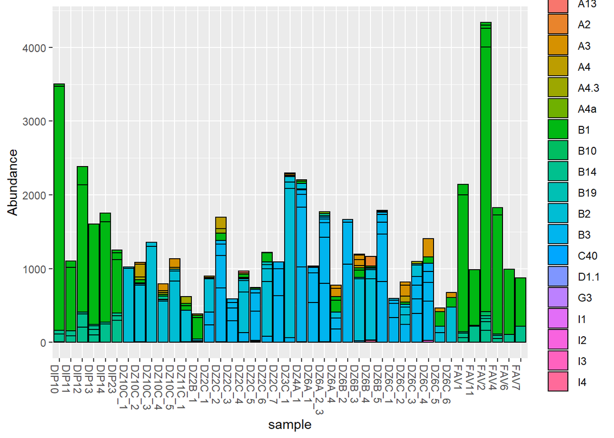

```r
#visusalize via counts rather than abundances:
plot_bar(ps, x = "sample", fill= "Class") #+ facet_wrap("tank")
```

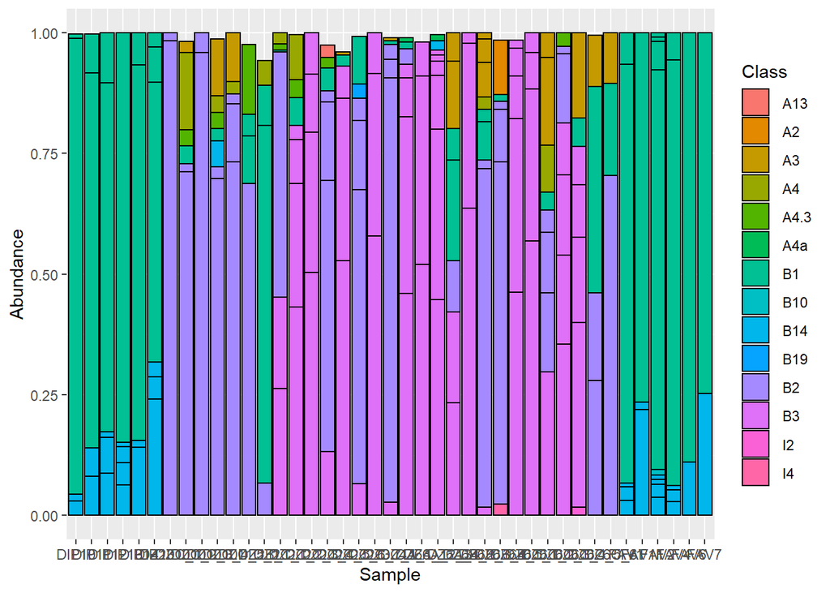

```r
#
#Obtain a csv file for the phyloseq data. Will give you the abundances for each sample and class. Useful for constructing the heatmap.
#Also, enables you to use ggplot, and construct more aesthetically pleasing plot.
psz <- psmelt(ps.top90)
write.csv(psz, file="Phyloseqoutputfinal.csv")
p <- ggplot(psz, aes(x=Sample, y=Abundance, fill=Class))
p + geom_bar(stat="identity", colour="black")
```

### Apply LULU

**FOR SYMBIODINIACEAE DATA ONLY**

First create a fasta file

```r
seqtab.nochim <- readRDS("final_seqtab_nochim.rds")
asv_seqs <- colnames(seqtab.nochim)
asv_headers <- vector(dim(seqtab.nochim)[2], mode="character")
for (i in 1:dim(seqtab.nochim)[2]) {
  asv_headers[i] <- paste(">ASV", i, sep="_")
}
```

making and writing out a fasta of our final ASV seqs:

```r
asv_fasta <- c(rbind(asv_headers, asv_seqs))
write(asv_fasta, "ITS_ASVs.fa")
```

```r
#install.packages("remotes")
library("remotes")
#install_github("https://github.com/tobiasgf/lulu.git")
library("lulu")
```

read in ASV table

```r
alldat=seqtab.nochim
ASV_IDs=substring(asv_headers, 2)
colnames(alldat)=ASV_IDs
head(alldat)
```

```
##       ASV_1 ASV_2 ASV_3 ASV_4 ASV_5 ASV_6 ASV_7 ASV_8 ASV_9 ASV_10 ASV_11
## DIP10  3311     0     0     0     0     0     0     0     0      0      0
## DIP11   858     0     0     0     0     0     0     0     0      0      0
## DIP12  1726     0     0     0     0     0     0     0     0      0      0
## DIP13  1360     0     0     0     0     0     0     0     0      0      0
## DIP14  1362     0     0     0     0     0     0     0     0      0      0
## DIP23   726     0     0     0     0     0     0     0     0      0      0
##       ASV_12 ASV_13 ASV_14 ASV_15 ASV_16 ASV_17 ASV_18 ASV_19 ASV_20 ASV_21
## DIP10      0      0      0      0      0      0      0      0      0      0
## DIP11     89      0      0      0      0     89     66      0      0      0
## DIP12    177      0      0      0      0    246    209      0      0      0
## DIP13    101      0      0      0      0      0     75      0      0      0
## DIP14      0      0      0      0      0      0      0      0      0      0
## DIP23    301      0      0      0      0     90     58      0      0      0
##       ASV_22 ASV_23 ASV_24 ASV_25 ASV_26 ASV_27 ASV_28 ASV_29 ASV_30 ASV_31
## DIP10      0      0      0      0    104      0      0      0      0      0
## DIP11      0      0      0      0      0      0      0      0      0      0
## DIP12      0      0      0      0     27      0      0      0      0      0
## DIP13      0      0      0      0     16      0      0      0      0      0
## DIP14      0    248      0      0     25      0      0      0      0      0
## DIP23      0      0      0      0     38      0      0      0      0      0
##       ASV_32 ASV_33 ASV_34 ASV_35 ASV_36 ASV_37 ASV_38 ASV_39 ASV_40 ASV_41
## DIP10      0      0      0      0      0      0      0      0      0      0
## DIP11      0      0      0      0      0      0      0      0      0      0
## DIP12      0      0      0      0      0      0      0      0      0      0
## DIP13      0      0      0      0      0      0      0      0      0      0
## DIP14      0      0      0      0      0    116      0      0      0      0
## DIP23      0      0      0      0      0      0      0      0      0      0
##       ASV_42 ASV_43 ASV_44 ASV_45 ASV_46 ASV_47 ASV_48 ASV_49 ASV_50 ASV_51
## DIP10      0      0      0      0      0      0      0      0      0     51
## DIP11      0      0      0      0      0      0      0      0      0      0
## DIP12      0      0      0      0      0      0      0      0      0      0
## DIP13      0      0      0      0      0      0      0      0     52      0
## DIP14      0      0      0      0      0      0      0      0      0      0
## DIP23      0      0      0      0      0      0      0      0      0      0
##       ASV_52 ASV_53 ASV_54 ASV_55 ASV_56 ASV_57 ASV_58 ASV_59 ASV_60 ASV_61
## DIP10      0      0      0      0      0      0      0      0      0      0
## DIP11      0      0      0      0      0      0      0      0      0      0
## DIP12      0      0      0      0      0      0      0      0      0      0
## DIP13      0      0      0      0      0      0      0      0      0      0
```

[output cut: 36 more lines]

```
## DIP23       0       0       0       0       0       0       0       0       0
##       ASV_111 ASV_112 ASV_113 ASV_114 ASV_115 ASV_116 ASV_117 ASV_118 ASV_119
## DIP10       0       0       0       0       0       0       0       0       0
## DIP11       0       0       0       0       0       0       0       3       0
## DIP12       0       0       0       0       0       0       0       0       0
## DIP13       0       0       0       0       0       0       0       0       0
## DIP14       0       0       0       0       0       0       0       0       0
## DIP23       0       0       0       0       0       0       0       0       0
##       ASV_120 ASV_121 ASV_122 ASV_123
## DIP10       0       0       0       2
## DIP11       0       0       0       0
## DIP12       0       0       0       0
## DIP13       0       0       0       0
## DIP14       0       0       0       0
## DIP23       0       0       0       0
```

Create a match list in your TERMINAL

```bash
module load blast+
makeblastdb -in ITS_ASVs.fa -parse_seqids -dbtype nucl

blastn -db ITS_ASVs.fa -outfmt '6 qseqid sseqid pident' -out match_list.txt -qcov_hsp_perc 80 -perc_identity 84 -query ITS_ASVs.fa
```

Back in R

```r
matchList<-read.table("match_list.txt")
head(matchList)
```

```
##      V1     V2      V3
## 1 ASV_1  ASV_1 100.000
## 2 ASV_1 ASV_68  99.643
## 3 ASV_1 ASV_66  99.643
## 4 ASV_1 ASV_61  99.643
## 5 ASV_1 ASV_58  99.643
## 6 ASV_1 ASV_25  99.643
```

```r
#Reformat ASV table to desired LULU format
ASVs<-data.frame(t(alldat[]))
head(ASVs)
```

```
##       DIP10 DIP11 DIP12 DIP13 DIP14 DIP23 DZ10C_1 DZ10C_2 DZ10C_3 DZ10C_4
## ASV_1  3311   858  1726  1360  1362   726       0       0       0       0
## ASV_2     0     0     0     0     0     0    1007       0       0       0
## ASV_3     0     0     0     0     0     0       0       0       0       0
## ASV_4     0     0     0     0     0     0       0       0       0       0
## ASV_5     0     0     0     0     0     0       0     772       0     556
## ASV_6     0     0     0     0     0     0       0       0       0       0
##       DZ10C_5 DZ11C_1 DZ2B_1 DZ2C_1 DZ2C_2 DZ2C_3 DZ2C_4 DZ2C_5 DZ2C_6 DZ2C_7
## ASV_1       0       0      0      0     99      0      0      0    120      0
## ASV_2       0       0      0      0      0      0      0      0    745      0
## ASV_3       0       0      0      0    735      0      0      0      0      0
## ASV_4       0       0      0      0    435      0      0      0     80      0
## ASV_5       0     427     26    457      0      0    157      0      0      0
## ASV_6       0       0      0    237      0    296      0    392      0    631
##       DZ3C_1 DZ4A_1 DZ6A_1 DZ6A_2_3 DZ6A_4 DZ6B_2 DZ6B_3 DZ6B_4 DZ6B_5 DZ6C_1
## ASV_1     15     33      0        0      0      0      0     17      0      0
## ASV_2   2023     71      0        0      0      0      0    826      0      0
## ASV_3      0   1015    539        0      0   1060      0      0    827    339
## ASV_4      0    808    404        0      0    568      0      0    643    188
## ASV_5      0      0      0        0      0      0    840      0      0      0
## ASV_6      0      0      0      792      0      0      0      0      0      0
##       DZ6C_2 DZ6C_3 DZ6C_4 DZ6C_5 DZ6C_6 FAV1 FAV11 FAV2 FAV4 FAV6 FAV7
## ASV_1      0      0     83    199    130 1859   752 3592 1615  880  655
## ASV_2    133      0      0    130    478    0     0    0    0    0    0
## ASV_3    243    389    248      0      0    0     0    0    0    0    0
## ASV_4      0    202    538      0      0    0     0    0    0    0    0
## ASV_5      0      0      0      0      0    0     0    0    0    0    0
## ASV_6      0      0      0      0      0    0     0    0    0    0    0
```

```r
curated_result <- lulu(ASVs, matchList,minimum_match=97)
summary(curated_result)
```

```r
nrow(curated_result$curated_table)
```

```
## [1] 68
```

```r
#retains 68 OTUs at 97% similarity;
#% similarity threshold is super variable, some people publish with 85% similarity
#There are no clear guidelines in the symbiodiniaceae community on what threshold to choose


NEWDAT=data.frame(curated_result$curated_table)

row.names(taxa)=ASV_IDs

ps <- phyloseq(otu_table(NEWDAT, taxa_are_rows=T),
               sample_data(samdf),
               tax_table(taxa))

#updating seqtab.nochim post lulu removal
seqtab.nochim=data.frame(t(otu_table(ps)))
```

### Rarefy

```r
library(vegan)
```

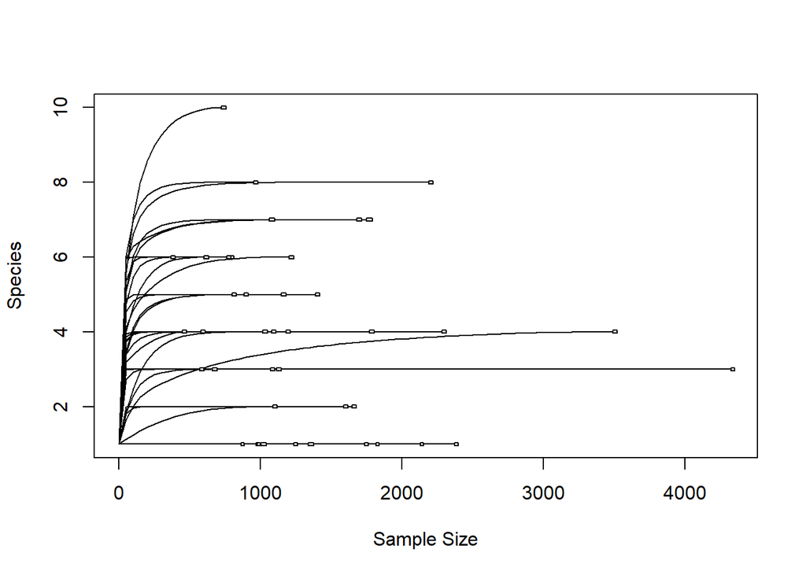

```r
rarecurve(t(otu_table(ps)), step=50, cex=0.005)
```

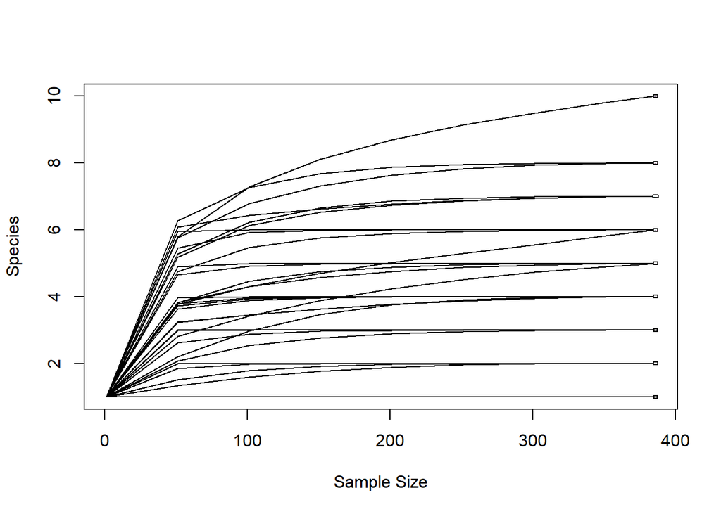

```r
#rarefy by minimum sample, this is another highly variable cutoff, some people do a cutoff by a particular sample size
#e.g. 1000 reads
seqtab.nochim.rare <- data.frame(rrarefy(seqtab.nochim,sample=min(sample_sums(ps))))
#check rarecurve post rarefying
rarecurve(seqtab.nochim.rare,step=50,cex=0.005)
```

### Trimming low abundance ASVs and purging outlier samples

```r
#install.packages("MCMC.OTU")
library(MCMC.OTU)
library(tibble)
#we trim on a rarefied dataset and a non-rarefied dataset because it is considered best practice
#to do downstream analyses
#using BOTH rarefied and unrarefied data to see how much the story changes.
```

FIRST we create a trimmed dataset from a non-rarefied dataset

```r
seqtab.4mcmc=add_column(seqtab.nochim, sample = row.names(seqtab.nochim), .after = 0)
#for columns parameter select only columns that correspond to ASVs
#otu.cut = cutoff for a fraction of total counts the OTU has to represent. This would depend on the methodology and nature of OTUs; for coral symbionts (Symbiodinium sp) the reasonable cutoff is 0.001 (Quigley et al, PLoS ONE 2014)
seqtab.trim=purgeOutliers(seqtab.4mcmc,count.columns=2:69,sampleZcut=-2.5,otu.cut=0.001,zero.cut=0.02)
```

```
## [1] "samples with counts below z-score -2.5 :"
## character(0)
## [1] "zscores:"
## named numeric(0)
## [1] "OTUs passing frequency cutoff  0.001 : 24"
## [1] "OTUs with counts in 0.02 of samples:"
##
## TRUE
##   24
```

^The above states that no samples are considered outliers, if there were any outliers we would need to remove them from the rarefied dataset as well and also from the list of samples using the below code

```r
row.names.remove <- c("B5","F9")
samdf.trim <- samdf[!(row.names(samdf) %in% row.names.remove), ]
```

SECOND we create a trimmed dataset from a rarefied dataset

```r
seqtab.rare.4mcmc=add_column(seqtab.nochim.rare, sample = row.names(seqtab.nochim.rare), .after = 0)
#for columns parameter select only columns that correspond to ASVs
seqtab.rare.trim=purgeOutliers(seqtab.rare.4mcmc,count.columns=2:69,sampleZcut=-2.5,otu.cut=0.0001,zero.cut=0.02)
```

```
## [1] "samples with counts below z-score -2.5 :"
##  [1] NA NA NA NA NA NA NA NA NA NA NA NA NA NA NA NA NA NA NA NA NA NA NA NA NA
## [26] NA NA NA NA NA NA NA NA NA NA NA NA NA NA NA NA
## [1] "zscores:"
## <NA> <NA> <NA> <NA> <NA> <NA> <NA> <NA> <NA> <NA> <NA> <NA> <NA> <NA> <NA> <NA>
##   NA   NA   NA   NA   NA   NA   NA   NA   NA   NA   NA   NA   NA   NA   NA   NA
## <NA> <NA> <NA> <NA> <NA> <NA> <NA> <NA> <NA> <NA> <NA> <NA> <NA> <NA> <NA> <NA>
##   NA   NA   NA   NA   NA   NA   NA   NA   NA   NA   NA   NA   NA   NA   NA   NA
## <NA> <NA> <NA> <NA> <NA> <NA> <NA> <NA> <NA>
##   NA   NA   NA   NA   NA   NA   NA   NA   NA
## [1] "OTUs passing frequency cutoff  1e-04 : 62"
## [1] "OTUs with counts in 0.02 of samples:"
##
## TRUE
##   62
```

```r
#Lets remake everything into phyloseq objects
#Rarefied only (no trim)
ps.rare <- phyloseq(otu_table(seqtab.nochim.rare, taxa_are_rows=F),
               sample_data(samdf),
               tax_table(taxa))
#Rarefied AND trimmed
ps.rare.trim <- phyloseq(otu_table(data.matrix(seqtab.rare.trim), taxa_are_rows=F),
                    sample_data(samdf),
                    tax_table(taxa))
#NOT rarefied, trimmed only
ps.trim <- phyloseq(otu_table(data.matrix(seqtab.trim), taxa_are_rows=F),
                         sample_data(samdf),
                         tax_table(taxa))
```

### Alpha Diversity

Visualize alpha-diversity - NOTE **Should be done on raw, untrimmed dataset**

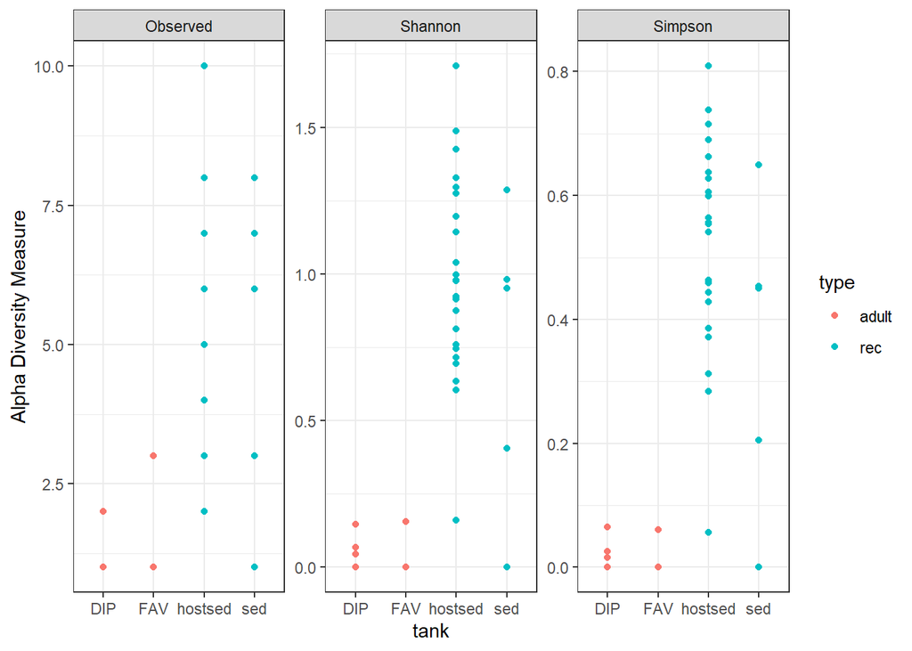

```r
plot_richness(ps.rare, x="tank", measures=c("Shannon", "Simpson","Observed"), color="type") + theme_bw()
```

### Beta Diversity

```r
library(cowplot)
library(vegan)
```

transform to relative abundance, you will need to do some transformation if not using rarefied data.

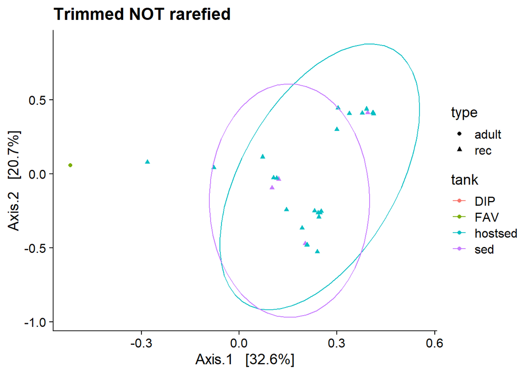

```r
ps.trim.rel <- transform_sample_counts(ps.trim, function(x) x / sum(x))
ord <- ordinate(ps.trim.rel, "PCoA", "bray")
plot_ordination(ps.trim.rel, ord,color="tank", shape="type")+
  stat_ellipse()+
  theme_cowplot()+
ggtitle("Trimmed NOT rarefied")
```

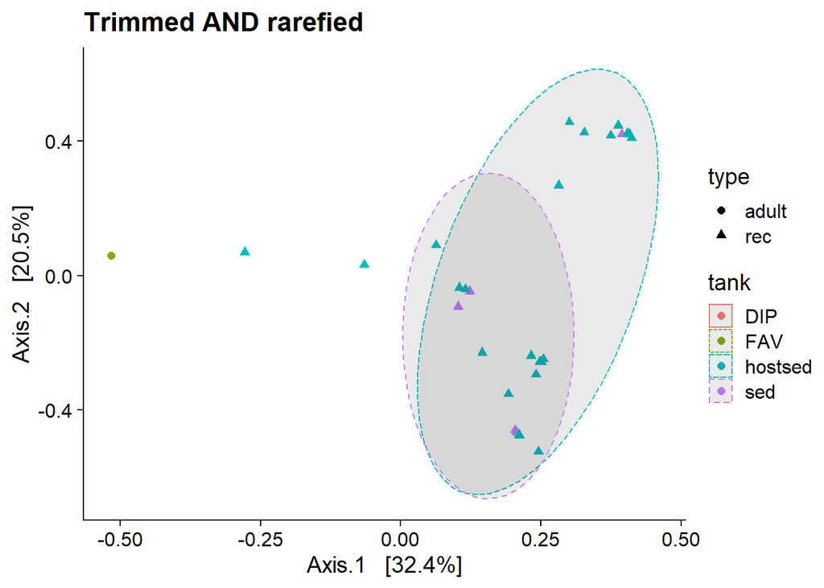

```r
ggplot <- plot_ordination(ps.rare.trim, ordinate(ps.rare.trim, "PCoA"), color="tank", shape="type")+
  geom_point(size=2)+
  stat_ellipse(level=0.8,aes(lty=tank),geom="polygon",alpha=0.1)+

  theme_cowplot()+

  ggtitle("Trimmed AND rarefied")

ggplot
```

```r
#Test for significance
#help on adonis here:
#https://thebiobucket.blogspot.com/2011/04/assumptions-for-permanova-with-adonis.html

#all
adonis(seqtab.rare.trim[-c(1)] ~ tank, data=samdf, permutations = 1000, method="bray")
```

```
##
## Call:
## adonis(formula = seqtab.rare.trim[-c(1)] ~ tank, data = samdf,      permutations = 1000, method = "bray")
##
## Permutation: free
## Number of permutations: 1000
##
## Terms added sequentially (first to last)
##
##           Df SumsOfSqs MeanSqs F.Model      R2   Pr(>F)
## tank       3    5.2036 1.73453  5.9593 0.32577 0.000999 ***
## Residuals 37   10.7694 0.29106         0.67423
## Total     40   15.9730                 1.00000
## ---
## Signif. codes:  0 '***' 0.001 '**' 0.01 '*' 0.05 '.' 0.1 ' ' 1
```